# Optimization In Security Trading

### Table of contents

- Part 1: Portfolio Optimization
  - A. Monte Carlo & Efficient Frontier
  - B. Objective functions
    - 1. SLSQP)
    - 2. L-BFGS-B
    - 3. CVXPY - ECOS solver
- Part 2: Optimal Order Execution
  - A. CVXPY
  - B. Genetic Algorithm
- Part 3: Option pricing
  - A. BFGS
  - B. Nelder-Mead
  - C. Conjugate Gradient
  - D. SLSQP
  - E. Visualizations
- Part 4: Hedging By Simulated Annealing
- References

## Part 1: Portfolio optimization

Portfolio optimization is a mathematical model proposed by Harry Markowitz in 1952 [1]. It's a theory that attempts to maximize portfolio expected return for a given amount of portfolio risk, or equivalently minimize risk for a given level of expected return, by carefully choosing the proportions of various assets. The key insight of the Markowitz model is that the risk of a portfolio is not simply the weighted average of the securities' individual risks, but also includes the correlation among the securities. This theory introduced the concept of efficient frontier, a set of optimal portfolios that offer the highest expected return for a defined level of risk or the lowest risk for a given level of expected return. Markowitz's theory emphasizes the power of diversification and has significantly influenced the practice of portfolio management [2].

[figure not shown]

Harry Markowitz

Building on the principles of Modern Portfolio Theory, this section of the project aims to maximize the Sharpe Ratio, a measure of risk-adjusted return, to determine the optimal portfolio composition. By leveraging optimization algorithms, we will systematically adjust the weights of various assets in the portfolio to find the combination that offers the highest expected return for a given level of risk, thereby providing an efficient tool for investment decision-making.

```python
# Imports

import math
import cvxpy as cp
import yfinance as yf
import pandas as pd
import requests
from bs4 import BeautifulSoup
import pandas as pd
import numpy as np
import matplotlib.pyplot as plt
from scipy.optimize import minimize
import seaborn as sns
from deap import base, creator, tools
import random

import scipy.stats as si
from sklearn.metrics import mean_absolute_error, mean_squared_error, r2_score
import sympy as sp
from scipy.optimize import minimize_scalar
```

```python
# To get a list of tickers, we will scrape the Wikipedia page that contains the list of S&P 500 companies.


def scrape_tickers():
    url = "https://en.wikipedia.org/wiki/List_of_S%26P_500_companies"
    response = requests.get(url)
    soup = BeautifulSoup(response.text, "html.parser")
    table = soup.find("table", {"class": "wikitable sortable"})
    tickers = []
    for row in table.findAll("tr")[1:]:
        ticker = row.findAll("td")[0].text.strip()
        tickers.append(ticker)

    return tickers


sp500_tickers = scrape_tickers()
sp500_tickers.count("")
```

```
0
```

No empty tickers.

```python
# Download the stock data using the yahoo finance library
data = yf.download(sp500_tickers, start="2020-03-31", end="2024-03-31")

# For this purpose, only the close prices are needed.
prices = data["Adj Close"]
```

```
[*********************100%%**********************]  503 of 503 completed

4 Failed downloads:
['GEV', 'SOLV']: Exception("%ticker%: Data doesn't exist for startDate = 1585627200, endDate = 1711857600")
['BRK.B']: Exception('%ticker%: No timezone found, symbol may be delisted')
['BF.B']: Exception('%ticker%: No price data found, symbol may be delisted (1d 2020-03-31 -> 2024-03-31)')
```

```python
# Drop the columns (tickers) where NA values are found
prices_clean = prices.dropna(axis=1)
prices_clean.isna().sum()
```

```
Ticker
A       0
AAL     0
AAPL    0
ABBV    0
ABT     0
       ..
XYL     0
YUM     0
ZBH     0
ZBRA    0
ZTS     0
Length: 494, dtype: int64
```

```python
# Calculate the daily returns of the stocks
returns = (
    prices_clean.pct_change().dropna()
)  # dropna to drop the first line with NA values (no return on the first day)
```

```python
returns.head()
```

| Ticker Date | A | AAL | AAPL | ABBV | ABT | ACGL | ACN | ADBE | ADI | ADM | ... | WTW | WY | WYNN | XEL | XOM | XYL | YUM | ZBH | ZBRA | ZTS |
| --- | --- | --- | --- | --- | --- | --- | --- | --- | --- | --- | --- | --- | --- | --- | --- | --- | --- | --- | --- | --- | --- |
| 2020-04-01 | -0.037699 | -0.123052 | -0.052617 | -0.036356 | -0.029654 | -0.085734 | -0.052554 | -0.053513 | -0.062019 | -0.037237 | ... | -0.080424 | -0.048968 | -0.102841 | -0.036816 | -0.011588 | -0.082297 | -0.012841 | -0.113277 | -0.038889 | -0.049027 |
| 2020-04-02 | 0.048897 | -0.058934 | 0.016687 | 0.023291 | 0.037482 | 0.011530 | 0.010279 | 0.009130 | 0.042930 | 0.013582 | ... | 0.014214 | -0.017370 | -0.024630 | 0.040289 | 0.076472 | 0.060733 | -0.023651 | 0.034364 | -0.012581 | 0.036723 |
| 2020-04-03 | -0.025868 | -0.066600 | -0.014371 | -0.023426 | 0.000126 | -0.064970 | -0.026365 | -0.034051 | -0.012999 | 0.009321 | ... | -0.008333 | -0.031566 | -0.079172 | -0.042370 | -0.029456 | -0.045741 | -0.041635 | -0.007551 | 0.022039 | -0.012238 |
| 2020-04-06 | 0.055950 | 0.011715 | 0.087237 | 0.032166 | 0.041284 | 0.098334 | 0.091357 | 0.086918 | 0.106747 | 0.032612 | ... | 0.116303 | 0.114733 | 0.169691 | 0.056861 | 0.032135 | 0.077521 | 0.113744 | 0.064450 | 0.077325 | 0.106274 |
| 2020-04-07 | -0.004438 | 0.075790 | -0.011582 | -0.004490 | -0.009670 | 0.031446 | -0.011623 | -0.031962 | 0.004697 | 0.005590 | ... | 0.018990 | 0.011111 | 0.072625 | -0.031398 | 0.019026 | 0.015340 | 0.012057 | 0.040535 | 0.002658 | -0.005363 |

5 rows × 494 columns

```python
# Create a function to calculate the portfolio's overall annualized returns and annualized volatility
def calculate_portfolio_performance(weights, returns):
    portfolio_return = (
        np.sum(returns.mean() * weights) * 252
    )  # Days that the stock market is open
    portfolio_volatility = np.sqrt(
        np.dot(weights.T, np.dot(returns.cov() * 252, weights))
    )
    return portfolio_return, portfolio_volatility


# Create a function to generate random weights for each stock in the portfolio, as a starting point
def generate_random_weights(number_of_stocks):
    weights = np.random.random(number_of_stocks)
    weights /= np.sum(weights)
    return weights
```

## A. Monte Carlo & Efficient Frontier

Monte Carlo simulation is a powerful technique for portfolio optimization, leveraging randomness to model and analyze the behavior of asset returns. By simulating thousands of potential future scenarios, it allows us to assess the probabilistic distribution of portfolio returns and risks. The portfolios generated through these simulations are evaluated based on the Sharpe ratio, which measures the excess return per unit of risk, calculated as the portfolio's return (minus the risk-free rate), divided by the portfolio's standard deviation [3].

Higher Sharpe ratios indicate more efficient portfolios. After evaluating the Sharpe ratios, the efficient frontier is plotted, representing the set of optimal portfolios offering the highest expected return for a given level of risk. Inspecting the efficient frontier helps in visualizing the trade-off between risk and return, guiding investors in selecting the most suitable asset allocation.

The Sharpe ratio is defined as:

$S(w) = Rp / σp$

Where:

- $S(w)$ is the Sharpe Ratio
- $Rp$ is the portfolio return
- $σp$ is the portfolio standard deviation
- $w$ is the vector of portfolio weights

[figure not shown]

William Sharpe

```python
# Get the stock names
stock_names = prices_clean.columns

# Run a Monte Carlo simulation to generate a large number of random portfolios
number_of_portfolios = 10000
number_of_stocks = len(stock_names)

# Initialize a list to store the portfolio data
portfolios = []

for _ in range(number_of_portfolios):
    weights = generate_random_weights(number_of_stocks)
    portfolio_return, portfolio_volatility = calculate_portfolio_performance(
        weights, returns
    )

    # Create a dictionary to store the data for this portfolio
    portfolio_data = {"return": portfolio_return, "volatility": portfolio_volatility}

    # Add the weights to the dictionary
    for i in range(number_of_stocks):
        portfolio_data[stock_names[i]] = weights[i]

    # Append the dictionary to the list
    portfolios.append(portfolio_data)
```

```python
# Convert the list of dictionaries to a DataFrame
portfolios = pd.DataFrame(portfolios)

# Calculate the Sharpe Ratios for the portfolios
portfolios["sharpe_ratio"] = portfolios["return"] / portfolios["volatility"]

# Find the portfolio with the highest Sharpe Ratio
max_sharpe_ratio_index = portfolios["sharpe_ratio"].idxmax()
```

```python
portfolios["sharpe_ratio"].iloc[max_sharpe_ratio_index]
```

```
1.3355611383037558
```

A Sharpe Ratio of 1.34 is generally considered good, however this can be improved by optimization methods.

```python
# A quick look at the portfolios
portfolios.head()
```

|  | return | volatility | A | AAL | AAPL | ABBV | ABT | ACGL | ACN | ADBE | ... | WY | WYNN | XEL | XOM | XYL | YUM | ZBH | ZBRA | ZTS | sharpe_ratio |
| --- | --- | --- | --- | --- | --- | --- | --- | --- | --- | --- | --- | --- | --- | --- | --- | --- | --- | --- | --- | --- | --- |
| 0 | 0.246348 | 0.197444 | 0.002398 | 0.003820 | 0.000647 | 0.000706 | 0.000590 | 0.000482 | 0.000394 | 0.000545 | ... | 0.001086 | 0.001931 | 0.001002 | 0.000335 | 0.000472 | 0.000606 | 0.001279 | 0.004184 | 0.000970 | 1.247688 |
| 1 | 0.247415 | 0.194292 | 0.000683 | 0.001164 | 0.002254 | 0.000109 | 0.003771 | 0.002085 | 0.003668 | 0.002888 | ... | 0.001579 | 0.000069 | 0.003046 | 0.003183 | 0.002458 | 0.004062 | 0.001561 | 0.000446 | 0.002347 | 1.273423 |
| 2 | 0.246056 | 0.191456 | 0.000653 | 0.001345 | 0.002184 | 0.000963 | 0.004004 | 0.002533 | 0.002393 | 0.001562 | ... | 0.001065 | 0.003308 | 0.002942 | 0.002973 | 0.003261 | 0.002370 | 0.001710 | 0.003306 | 0.002222 | 1.285184 |
| 3 | 0.248540 | 0.194811 | 0.003171 | 0.003022 | 0.001833 | 0.003167 | 0.003218 | 0.002953 | 0.002648 | 0.002097 | ... | 0.003653 | 0.003019 | 0.003229 | 0.001654 | 0.001738 | 0.002388 | 0.001231 | 0.002822 | 0.002789 | 1.275802 |
| 4 | 0.249345 | 0.193808 | 0.000722 | 0.003468 | 0.002173 | 0.003441 | 0.002855 | 0.002530 | 0.002816 | 0.003318 | ... | 0.003859 | 0.000147 | 0.002054 | 0.002779 | 0.002643 | 0.000349 | 0.003662 | 0.001566 | 0.003783 | 1.286559 |

5 rows × 497 columns

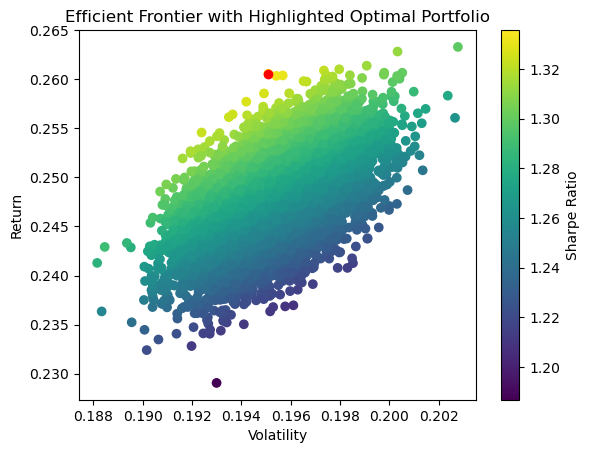

```python
# Plot the simulated portfolios
plt.scatter(
    portfolios["volatility"],
    portfolios["return"],
    c=portfolios["sharpe_ratio"],
    cmap="viridis",
)
plt.colorbar(label="Sharpe Ratio")
plt.xlabel("Volatility")
plt.ylabel("Return")

# Highlight the portfolio with the highest Sharpe Ratio
plt.scatter(
    portfolios.loc[max_sharpe_ratio_index, "volatility"],
    portfolios.loc[max_sharpe_ratio_index, "return"],
    color="r",
)
plt.title("Efficient Frontier with Highlighted Optimal Portfolio")

plt.show()
```

The plotted efficient frontier visually represents the set of optimal portfolios that offer the highest expected return for a given level of risk. The highlighted point on this frontier signifies the optimal portfolio with the maximum Sharpe Ratio. This portfolio provides the best risk-adjusted return, making it an ideal choice for investors seeking to maximize their returns while efficiently managing risk.

As an investor you seek the largest return for the smallest volatility, the yellow colored portfolios in the top left corner are considered good options and mark the efficient frontier.

However, some remarks:

1. The efficient frontier is based on historical returns and volatilities, and assumes that these will remain the same in the future. This may not always be the case, so it's important to consider other factors and not rely solely on the efficient frontier when making investment decisions.
2. The efficient frontier does not take into account the investor's risk tolerance. Some investors may be willing to accept a higher level of risk for the potential of higher returns, while others may prefer a lower-risk portfolio even if it offers lower returns.
3. The efficient frontier assumes that returns are normally distributed, which may not always be true in real-world markets. Extreme events (also known as "black swan" events) can cause actual returns to deviate significantly from the expected returns.
4. The efficient frontier is a static model and does not take into account changes in the market or the investor's circumstances. It's important to regularly review and adjust the portfolio as needed.
5. Lastly, transaction costs are not considered in the model. In reality, frequent trading to maintain the optimal portfolio can incur significant costs, which can reduce the portfolio's net return.

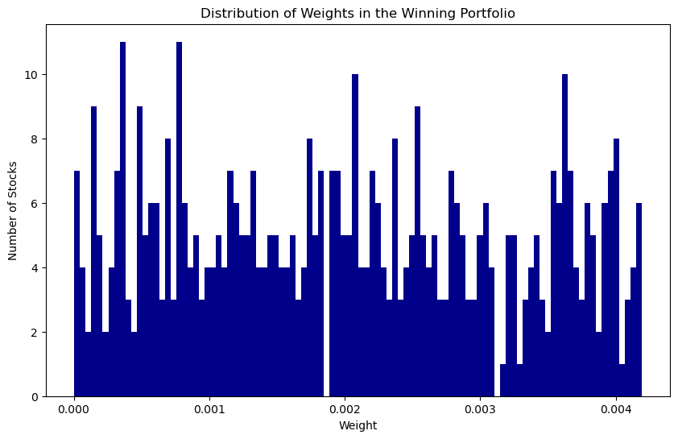

```python
# Find the portfolio with the highest return
winning_portfolio = portfolios.iloc[max_sharpe_ratio_index]

# Remove the 'return' and 'volatility' entries
winning_weights = winning_portfolio.drop(["return", "volatility", "sharpe_ratio"])

winning_weights.hist(bins=100, figsize=(10, 6), grid=False, color="darkblue")
plt.title("Distribution of Weights in the Winning Portfolio")
plt.xlabel("Weight")
plt.ylabel("Number of Stocks")
plt.show()
```

As an investor, portfolio diversification is important as a high concentration in a single stock can lead to high risk. This distribution of weights shows that the winning portfolio is well-diversified, with no single stock having a disproportionately high weight.

However, again a couple of remarks:

1. Diversification helps to reduce unsystematic risk - the risk associated with individual stocks. By investing in a variety of assets, you can reduce the impact of any one asset performing poorly on the overall portfolio.
2. It's important to note that diversification is not just about having a large number of assets, but also about having assets that are not highly correlated. Assets that move in opposite directions can help to smooth out the overall portfolio returns.
3. While diversification can help to reduce risk, it can also limit potential returns. A portfolio that is heavily weighted towards a single asset that performs well will have higher returns than a diversified portfolio.
4. Diversification is a strategy that should be tailored to the individual investor's risk tolerance and investment goals. Some investors may prefer a more concentrated portfolio if they are willing to accept higher risk for the potential of higher returns.
5. Lastly, it's important to regularly review and rebalance the portfolio to maintain the desired level of diversification. Over time, some assets may perform better than others, leading to an imbalance in the portfolio weights.

## B. Objective functions

### 1. SLSQP (Sequential Least Squares Programming)

Sequential Least Squares Programming (SLSQP) is an optimization algorithm used to solve constrained optimization problems.

The SLSQP algorithm works by iteratively approximating the solution using a **quadratic approximation** of the objective function and the constraints. It starts with an initial guess for the values of the variables and then iteratively updates them until convergence is achieved.

During each iteration, SLSQP solves a quadratic programming subproblem to find the search direction and step size for updating the variables. It takes into account the gradients and Hessians of the objective function and the constraints to guide the search.

The objective function is the Sharpe Ratio: $S(w) = Rp / σp$

Subject to constraints:

$∑wi = 1$, for all i in {1, 2, ..., n}

$0 ≤ wi ≤ 1$, for all i in {1, 2, ..., n}

Where:

- $S(w)$ is the Sharpe Ratio
- $Rp$ is the portfolio return
- $σp$ is the portfolio standard deviation
- w is the vector of portfolio weights
- n is the number of stocks in the portfolio

```python
# Calculate returns from price data
returns = prices_clean.pct_change().dropna()


# Define the objective function (negative Sharpe Ratio)
def objective(weights):
    portfolio_return = np.sum(returns.mean() * weights) * 252
    portfolio_volatility = np.sqrt(
        np.dot(weights.T, np.dot(returns.cov() * 252, weights))
    )
    sharpe_ratio = portfolio_return / portfolio_volatility
    return -sharpe_ratio  # We negate because we want to maximize the Sharpe Ratio


# Define the constraints (weights must sum to 1)
constraints = {"type": "eq", "fun": lambda weights: np.sum(weights) - 1}

number_of_stocks = prices_clean.shape[1]

# Define the bounds (weights must be between 0 and 1 because we wont short)
bounds = tuple((0, 1) for _ in range(number_of_stocks))

# Initial guess for the weights (equal distribution)
init_guess = np.array(
    number_of_stocks
    * [
        1.0 / number_of_stocks,
    ]
)

# Run the optimizer
result = minimize(
    objective,
    init_guess,
    method="SLSQP",
    bounds=bounds,
    constraints=constraints,
    options={"ftol": 1e-06},
)

# The optimal weights are in result.x
optimal_weights = result.x

print(optimal_weights[0:20])
```

```
[4.24359702e-15 6.87632051e-14 1.26157768e-14 7.19000579e-02
 8.32972194e-15 1.31365204e-14 8.69092799e-15 4.01209987e-14
 1.08952270e-14 7.85521333e-15 7.24669602e-16 6.17358454e-14
 3.37476626e-15 1.08183169e-14 5.76046200e-14 1.39667536e-14
 3.41742645e-15 9.95642829e-15 2.42939948e-14 6.06753343e-15]
```

```python
print("The sharpe ratio is {}".format(-result.fun))
```

```
The sharpe ratio is 2.8745697499215974
```

A sharpe ratio of 2.87 is a very good result and already a big improvement from the optimal portfolio obtained from monte carlo simulations.

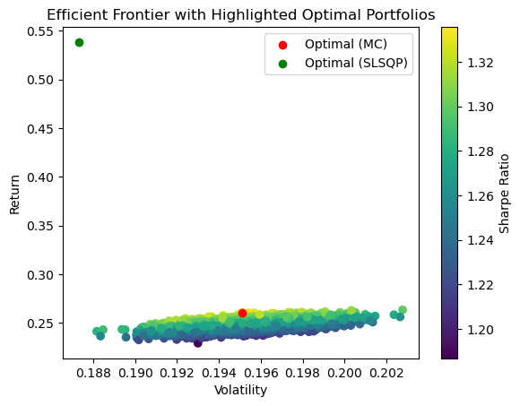

```python
# Calculate the return and volatility of the optimal portfolio
optimal_portfolio_return = np.sum(returns.mean() * optimal_weights) * 252
optimal_portfolio_volatility = np.sqrt(
    np.dot(optimal_weights.T, np.dot(returns.cov() * 252, optimal_weights))
)

# Plot the simulated portfolios
plt.scatter(
    portfolios["volatility"],
    portfolios["return"],
    c=portfolios["sharpe_ratio"],
    cmap="viridis",
)
plt.colorbar(label="Sharpe Ratio")
plt.xlabel("Volatility")
plt.ylabel("Return")

# Highlight the portfolio with the highest Sharpe Ratio from Monte Carlo simulations
plt.scatter(
    portfolios.loc[max_sharpe_ratio_index, "volatility"],
    portfolios.loc[max_sharpe_ratio_index, "return"],
    color="r",
    label="Optimal (MC)",
)

# Plot the optimal portfolio from SLSQP optimization
plt.scatter(
    optimal_portfolio_volatility,
    optimal_portfolio_return,
    color="g",
    label="Optimal (SLSQP)",
)

plt.title("Efficient Frontier with Highlighted Optimal Portfolios")
plt.legend()

plt.show()
```

Comparing the optimal portfolio from SLSQP with the portfolios from the Monte Carlo simulations, we can already see a large increase in sharpe ratio, moving further top left. This was of course expected as Monte Carlo relies on random sampling while SLSQP, uses a systematic approach.

### 2. L-BFGS-B

The BFGS (Broyden-Fletcher-Goldfarb-Shanno) method is an optimization algorithm used to solve unconstrained optimization problems. It belongs to the class of quasi-Newton methods, which aim to find the minimum of a function without explicitly computing its derivatives. The BFGS method approximates the Hessian matrix of the objective function using a series of rank-one updates. The Hessian matrix represents the second-order derivatives of the objective function and provides information about the curvature of the function's surface. By iteratively updating the approximation of the Hessian matrix, the BFGS method converges towards the minimum of the function. The BFGS method is known for its good convergence properties and is widely used in optimization problems. It combines the benefits of gradient-based methods (which use first-order derivatives) and Newton's method (which uses second-order derivatives) by approximating the Hessian matrix without explicitly computing it.

The L-BFGS-B variant is a limited-memory version of the BFGS method that is specifically designed for solving optimization problems with bound constraints. The "L" in L-BFGS-B stands for "limited-memory," which means that it stores a limited number of past iterations to approximate the Hessian matrix. The L-BFGS-B variant is particularly useful when dealing with large-scale optimization problems where the Hessian matrix is too expensive to compute or store. It uses a limited-memory approach to approximate the Hessian matrix efficiently, making it suitable for problems with a large number of variables. In addition to the BFGS updates, the L-BFGS-B variant also incorporates bound constraints into the optimization process. Bound constraints restrict the values of the variables within a specified range. The L-BFGS-B method ensures that the optimization process respects these constraints and finds the optimal solution within the given bounds.

[figure not shown]

From left to right: Broyden, Fletcher, Goldfarb, and Shanno.

Maximize: $S(w) = Rp / σp$

Subject to:

$0 ≤ wi ≤ 1$, for all i in {1, 2, ..., n}

Where:

- $S(w)$ is the Sharpe Ratio
- $Rp$ is the portfolio return
- $σp$ is the portfolio standard deviation
- w is the vector of portfolio weights
- n is the number of stocks in the portfolio

```python
# Calculate returns from price data
returns = prices_clean.pct_change().dropna()


# Define the objective function (negative Sharpe Ratio)
def objective(weights):
    portfolio_return = np.sum(returns.mean() * weights) * 252
    portfolio_volatility = np.sqrt(
        np.dot(weights.T, np.dot(returns.cov() * 252, weights))
    )
    sharpe_ratio = portfolio_return / portfolio_volatility
    return -sharpe_ratio  # We negate because we want to maximize the Sharpe Ratio


number_of_stocks = prices_clean.shape[1]

# Define the bounds (weights must be between 0 and 1 because we wont short)
bounds = tuple((0, 1) for _ in range(number_of_stocks))

# Initial guess for the weights (equal distribution)
init_guess = np.array(
    number_of_stocks
    * [
        1.0 / number_of_stocks,
    ]
)

# Run the optimizer
result = minimize(
    objective, init_guess, method="L-BFGS-B", bounds=bounds, options={"ftol": 1e-06}
)

# The optimal weights are in result.x
optimal_weights = result.x

# Normalize the weights so they sum to 1 since this method does not support constraints
optimal_weights = optimal_weights / np.sum(optimal_weights)
print(optimal_weights[0:20])
```

```
[0.         0.         0.00362507 0.01051981 0.         0.00520306
 0.         0.         0.         0.00030021 0.         0.
 0.         0.         0.         0.00224791 0.00238827 0.00023901
 0.0071038  0.        ]
```

```python
print("The sharpe ratio is {}".format(-result.fun))
```

```
The sharpe ratio is 2.0733289691717607
```

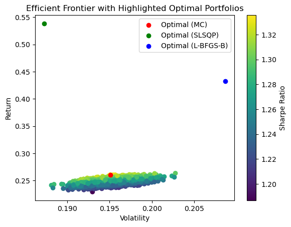

```python
# Calculate the return and volatility of the optimal portfolio from L-BFGS-B optimization
optimal_portfolio_return_lbfgsb = np.sum(returns.mean() * optimal_weights) * 252
optimal_portfolio_volatility_lbfgsb = np.sqrt(
    np.dot(optimal_weights.T, np.dot(returns.cov() * 252, optimal_weights))
)

# Plot the simulated portfolios
plt.scatter(
    portfolios["volatility"],
    portfolios["return"],
    c=portfolios["sharpe_ratio"],
    cmap="viridis",
)
plt.colorbar(label="Sharpe Ratio")
plt.xlabel("Volatility")
plt.ylabel("Return")

# Highlight the portfolio with the highest Sharpe Ratio from Monte Carlo simulations
plt.scatter(
    portfolios.loc[max_sharpe_ratio_index, "volatility"],
    portfolios.loc[max_sharpe_ratio_index, "return"],
    color="r",
    label="Optimal (MC)",
)

# Plot the optimal portfolio from SLSQP optimization
plt.scatter(
    optimal_portfolio_volatility,
    optimal_portfolio_return,
    color="g",
    label="Optimal (SLSQP)",
)

# Plot the optimal portfolio from L-BFGS-B optimization
plt.scatter(
    optimal_portfolio_volatility_lbfgsb,
    optimal_portfolio_return_lbfgsb,
    color="b",
    label="Optimal (L-BFGS-B)",
)

plt.title("Efficient Frontier with Highlighted Optimal Portfolios")
plt.legend()

plt.show()
```

However, it's worth noting that this portfolio exhibits a slightly higher volatility compared to the other methods. The increase is only about +- 0.02 in absolute terms, which still makes it a very viable option for investors.

### 3. CVXPY ECOS

The ECOS solver is an optimization solver that is commonly used for solving convex optimization problems. It stands for Embedded Conic Solver and is based on the second-order cone programming (SOCP) framework.

The ECOS solver utilizes the conic programming approach, which allows it to handle a wide range of convex optimization problems efficiently. It can handle linear constraints, second-order cone constraints, and exponential cone constraints.

The algorithm used by ECOS is an interior-point method, specifically a primal-dual interior-point method. This method iteratively solves a sequence of barrier subproblems, which are optimization problems with a logarithmic barrier term added to the objective function. The barrier term ensures that the iterates stay within the feasible region.

At each iteration, the solver computes search directions for the primal and dual variables, updates the iterates, and checks for convergence. The process continues until a stopping criterion is met, such as reaching a desired level of accuracy or the maximum number of iterations.

Here we dont optimize the Sharpe Ratio directly but we maximize the returns while setting a target volatility as boundary. As a target volatility, we try to push the boundaries by setting it lower than the already obtained volatilities, at 0.15.

[figure not shown]

CVXPY

Maximize: $Rp(w) = ∑wi * ri$

Constraints:

- $∑wi = 1$, for all i in {1, 2, ..., n}
- $0 ≤ wi ≤ 1$, for all i in {1, 2, ..., n}
- $σp(w)$ ≤ target_volatility

Where:

- $Rp(w)$ is the portfolio return
- $ri$ is the return of stock i
- $σp(w)$ is the portfolio standard deviation
- $w$ is the vector of portfolio weights
- n is the number of stocks in the portfolio
- target_volatility is the desired portfolio volatility

```python
target_volatility = 0.15


# Define the weights variable
weights = cp.Variable(number_of_stocks)

# Define the objective function
portfolio_return = np.array(returns.mean()) * weights * 252
portfolio_volatility = cp.quad_form(weights, returns.cov() * 252)

# Define the constraints
constraints = [
    cp.sum(weights) == 1,
    weights >= 0,
    weights <= 1,
    portfolio_volatility <= target_volatility**2,
]  # Add a constraint on the portfolio volatility

# Define the problem and solve it using the ECOS solver
problem = cp.Problem(cp.Maximize(portfolio_return), constraints)
problem.solve(solver=cp.ECOS)

# The optimal weights are in weights.value
optimal_weights = weights.value

# Calculate the portfolio return and volatility with the optimal weights
optimal_return = np.sum(returns.mean() * optimal_weights) * 252
optimal_volatility = np.sqrt(
    np.dot(optimal_weights.T, np.dot(returns.cov() * 252, optimal_weights))
)

# Calculate the Sharpe ratio
sharpe_ratio = optimal_return / optimal_volatility
```

```python
print("The sharpe ratio is {}".format(sharpe_ratio))
```

```
The sharpe ratio is 2.7333376172053243
```

This Sharpe Ratio is better than the one we obtained by the Monte Carlo simulations and the L-BFGS-B but still slightly worse than the SLSQP method. Important to notice is the difference in runtimes. The ECOS solver was way faster than the other 2 methods.

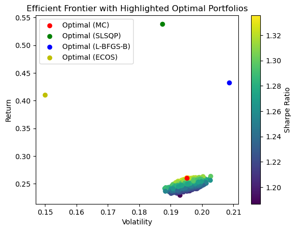

```python
# Plot the simulated portfolios
plt.scatter(
    portfolios["volatility"],
    portfolios["return"],
    c=portfolios["sharpe_ratio"],
    cmap="viridis",
)
plt.colorbar(label="Sharpe Ratio")
plt.xlabel("Volatility")
plt.ylabel("Return")

# Highlight the portfolio with the highest Sharpe Ratio from Monte Carlo simulations
plt.scatter(
    portfolios.loc[max_sharpe_ratio_index, "volatility"],
    portfolios.loc[max_sharpe_ratio_index, "return"],
    color="r",
    label="Optimal (MC)",
)

# Plot the optimal portfolio from SLSQP optimization
plt.scatter(
    optimal_portfolio_volatility,
    optimal_portfolio_return,
    color="g",
    label="Optimal (SLSQP)",
)

# Plot the optimal portfolio from L-BFGS-B optimization
plt.scatter(
    optimal_portfolio_volatility_lbfgsb,
    optimal_portfolio_return_lbfgsb,
    color="b",
    label="Optimal (L-BFGS-B)",
)

# Plot the optimal portfolio from ECOS optimization
plt.scatter(optimal_volatility, optimal_return, color="y", label="Optimal (ECOS)")

plt.title("Efficient Frontier with Highlighted Optimal Portfolios")
plt.legend()

plt.show()
```

As the optimal volatility was set lower than that of the other portfolios, this is accompanied by a decrease in return. When the volatility was set to match that of the SLSQP portfolio, the returns were also approximately equal. This makes the ECOS solver equally effective, but more efficient and flexible, as we can manually set the target volatility.

**Conclusion**

Sharpe Ratio's

[output not shown]

Runtimes

| Rank | Method | Runtime |
| --- | --- | --- |
| 1 | ECOS | 2.2s |
| 2 | Monte Carlo | 2m 31s |
| 3 | SLSQP | 2m 56s |
| 4 | L-BFGS-B | 4m 8s |

In conclusion, while the SLSQP method yielded the highest Sharpe ratio, it's important to note that when the volatility was set to the same value for both SLSQP and ECOS, they produced equivalent results. However, the ECOS method demonstrated superior efficiency, completing the task in just 2.2 seconds, compared to SLSQP's runtime of nearly 3 minutes.

The L-BFGS-B method, while still providing a respectable Sharpe ratio, was the least efficient in terms of runtime. The Monte Carlo method, despite its longer runtime, fell short in terms of the Sharpe ratio.

Therefore, considering both the Sharpe ratio and runtime, the ECOS solver emerges as the most efficient method for portfolio optimization in this analysis. It not only provides flexibility in setting the target volatility but also delivers strong performance in a fraction of the time compared to the other methods.

**ADDENDUM**:

To put the results into perspective, it's worth noting that two of the best performing hedge funds in history, Citadel LLC and Renaissance Technologies' Medallion Fund, have reported a long-running Sharpe ratio of around 2.5. This is a testament to their exceptional risk-adjusted performance over a sustained period.

[figure not shown]

Jim Simons, 2007

In honor of the late Jim Simons, who recently passed away on May 10, 2024. He was a renowned mathematician and hedge fund manager, best known as the founder of Renaissance Technologies. He is widely recognized for his contributions to the field of quantitative finance, pioneering the use of mathematical models for investment strategies. Simons' innovative approach revolutionized the industry and set the standard for many modern hedge funds. Beyond his financial career, he was also a dedicated philanthropist, contributing significantly to scientific and educational causes. His legacy continues to inspire and influence the world of finance and beyond.

## Part 2: Optimal Order Execution

In the world of finance and trading, the execution of large orders can significantly impact the market, often leading to unfavorable price movements. This is particularly true in the case of large institutional investors or hedge funds, whose trades can represent a substantial portion of the daily trading volume. This market impact can erode the potential profits from a trade, making the strategy less effective. Therefore, it becomes crucial to devise trading strategies that minimize this impact, ensuring the best possible execution price [4].

Optimal order execution strategies aim to address this issue. They seek to find the best way to execute a large order over a period of time, minimizing the market impact and, consequently, the cost of trading. This is achieved by breaking down the large order into smaller trades and executing them strategically over time.

[figure not shown]

Example of an orderbook

In this project, we will be exploring one such strategy. We want to minimize the market disturbance caused by our trades. We'll model the disturbance at each tick as the price impact of our trades, which is the product of the trade size and the difference between the ask volume-weighted average price (VWAP) and bid VWAP. This is a model that aims to limit the price impact of our trades.

Our objective function is then:

Minimize: $∑ (I_i)^2$ for all i from 1 to N

- $I_i$ as the price impact at tick i caused by our trade.
- $T_i$ as the volume of trades at tick i.
- $O$ as the total order size.
- N as the number of ticks

Our constraints are:

- The total volume of trades must equal the order size: $∑ T_i = O$ for all i from 1 to N
- Each trade must be non-negative: $T_i ≥ 0$ for all i from 1 to N

We then solve this optimization problem to find the optimal trade sizes that minimize the total price impact. We also compare the performance of this strategy with a simple strategy that sells an equal number of shares at each tick. The performance is evaluated based on the total cost, which is the sum of the price impacts of all trades.

```python
class OrderBookSimulator:
    def __init__(self):
        self.order_book = pd.DataFrame(
            {
                "bid_price": np.arange(90, 100, dtype=float)[::-1],
                "bid_size": np.random.randint(1, 10, 10),
                "ask_price": np.arange(101, 111, dtype=float),
                "ask_size": np.random.randint(1, 10, 10),
            }
        )
        self.order_book_history = []

    def update_order_book(self):
        # Randomly update the sizes
        self.order_book["bid_size"] = np.random.randint(1, 10, 10)
        self.order_book["ask_size"] = np.random.randint(1, 10, 10)

        # If the lowest ask price = the highest bid price + 1
        if self.order_book["ask_price"].min() == self.order_book["bid_price"].max() + 2:
            # The bid side may only move with -1
            if np.random.rand() < 0.1:
                self.order_book["bid_price"] -= 1
            # The ask side may only move with 1
            if np.random.rand() < 0.1:
                self.order_book["ask_price"] += 1
        else:
            if np.random.rand() < 0.5:
                if np.random.rand() < 0.5:
                    self.order_book["bid_price"] -= 1
                else:
                    self.order_book["bid_price"] += 1
            else:
                if np.random.rand() < 0.5:
                    self.order_book["ask_price"] -= 1
                else:
                    self.order_book["ask_price"] += 1
        # Add the current state of the order book to the history
        self.order_book_history.append(self.order_book.copy())
```

```python
# Run the simulation for 1000 ticks
simulator = OrderBookSimulator()
ticks = 100
for _ in range(ticks):
    simulator.update_order_book()
```

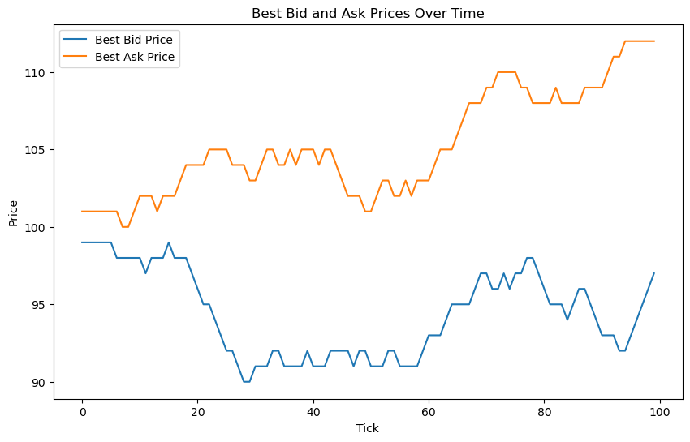

```python
# Visualisation
# Extract the best bid and ask prices at each tick
best_bid_prices = [df["bid_price"].max() for df in simulator.order_book_history]
best_ask_prices = [df["ask_price"].min() for df in simulator.order_book_history]

# Create a plot
plt.figure(figsize=(10, 6))
plt.plot(range(ticks), best_bid_prices, label="Best Bid Price")
plt.plot(range(ticks), best_ask_prices, label="Best Ask Price")
plt.xlabel("Tick")
plt.ylabel("Price")
plt.title("Best Bid and Ask Prices Over Time")
plt.legend()
plt.show()
```

In this model, the price impact of a trade is calculated as the absolute value of the product of the trade size and the difference between the ask VWAP and bid VWAP. This means that for a given price difference, a smaller trade size will result in a smaller price impact.

The intuition behind this is that in a market with a larger spread between the bid and ask prices (which is reflected in a larger difference between the ask VWAP and bid VWAP), each trade has a larger potential to move the market price. This is because the market is less liquid, so a given amount of trading volume has a larger effect on the price.

By making smaller trades when the price difference is large, a trader can reduce the price impact of their trades, which can help to minimize the cost of trading. This is the strategy that the model is trying to implement by minimizing the sum of squares of the price impacts.

However, this is a simplified model and doesn't take into account many factors that could affect the price impact of trades in a real-world market, such as the depth of the market beyond the top level and the reaction of other market participants to the trades.

## A. CVXPY

The OptimalExecution class solves an optimization problem to find the optimal strategy for executing trades. The optimization method used is convex optimization. Specifically, the objective function to be minimized is the sum of squares of price impacts. A price impact is calculated as the absolute value of the trade size times the difference between the volume-weighted average price (VWAP) of the ask and bid. Mathematically, the objective function can be represented as:

$Σ (|x[i]|$ * (ask_vwap[i] - bid_vwap[i]))$^2$

where:

- x[i] is the trade size at time i
- ask_vwap[i] and bid_vwap[i] are the VWAP of the ask and bid at time i, respectively.

The constraint is that the sum of the trade sizes must equal the total number of shares to be traded. Mathematically, this constraint can be represented as:

$Σ x[i]$ = total shares

```python
class OptimalExecution:
    def __init__(self, simulator, total_shares):
        self.simulator = simulator
        self.total_shares = total_shares

    def run(self):
        # Number of ticks
        n = len(self.simulator.order_book_history)

        # Trade sizes
        x = cp.Variable(n)

        # Price impacts
        impacts = []
        for i in range(n):
            order_book = self.simulator.order_book_history[i]
            bid_vwap = (
                order_book["bid_price"] * order_book["bid_size"]
            ).sum() / order_book["bid_size"].sum()
            ask_vwap = (
                order_book["ask_price"] * order_book["ask_size"]
            ).sum() / order_book["ask_size"].sum()
            impact = cp.abs(x[i]) * (ask_vwap - bid_vwap)
            impacts.append(impact)

        # Objective function
        objective = cp.Minimize(cp.sum_squares(cp.hstack(impacts)))

        # Constraints
        constraints = [cp.sum(x) == self.total_shares]

        # Problem
        problem = cp.Problem(objective, constraints)

        # Solve the problem
        problem.solve()

        return x.value

    def evaluate(self, trade_sizes):
        # Number of ticks
        n = len(self.simulator.order_book_history)

        # Price impacts and prices
        impacts = []
        prices = []
        for i in range(n):
            order_book = self.simulator.order_book_history[i]
            bid_vwap = (
                order_book["bid_price"] * order_book["bid_size"]
            ).sum() / order_book["bid_size"].sum()
            ask_vwap = (
                order_book["ask_price"] * order_book["ask_size"]
            ).sum() / order_book["ask_size"].sum()
            impact = abs(trade_sizes[i]) * (ask_vwap - bid_vwap)
            impacts.append(impact)
            prices.append(
                (ask_vwap + bid_vwap) / 2
            )  # Use the midpoint of the VWAPs as the trade price

        # Total cost
        total_cost = np.sum(np.array(impacts))

        # Variance of trade sizes
        variance_of_trade_sizes = np.var(trade_sizes)

        print(f"Total cost: {total_cost}")
        print(f"Variance of trade sizes: {variance_of_trade_sizes}")

    def evaluate_even_strategy(self):
        # Number of ticks
        n = len(self.simulator.order_book_history)

        # Trade size for the even strategy
        even_trade_size = self.total_shares / n

        # Price impacts
        impacts = []
        for i in range(n):
            order_book = self.simulator.order_book_history[i]
            bid_vwap = (
                order_book["bid_price"] * order_book["bid_size"]
            ).sum() / order_book["bid_size"].sum()
            ask_vwap = (
                order_book["ask_price"] * order_book["ask_size"]
            ).sum() / order_book["ask_size"].sum()
            impact = even_trade_size * (ask_vwap - bid_vwap)
            impacts.append(impact)

        # Total cost
        total_cost = np.sum(np.array(impacts))

        print(f"Total cost of even strategy: {total_cost}")


strategy_optimal = OptimalExecution(simulator, 1000)
trade_sizes_optimal = strategy_optimal.run()
strategy_optimal.evaluate(trade_sizes_optimal)
strategy_optimal.evaluate_even_strategy()
```

```
Total cost: 17173.52022160703
Variance of trade sizes: 43.72505518557286
Total cost of even strategy: 19897.7981041615
```

The optimal execution strategy resulted in a lower total cost of 17173.52 compared to the even strategy, which had a total cost of 19897.80. Additionally, the optimal execution strategy had a variance of trade sizes of 43.73, indicating a more dynamic adjustment of trade sizes over time.

## B. Genetic Algorithm

Genetic Algorithms (GAs) are a type of evolutionary algorithm inspired by the process of natural selection. They generate solutions to optimization problems using techniques such as mutation, crossover (recombination), and selection.

[figure not shown]

Illustration of a genetic algorithm

The OptimalExecutionGA class uses a GA to solve an optimization problem for executing trades. The objective function to be minimized is the total cost of trades, calculated as the sum of price impacts. A price impact is calculated as the absolute value of the trade size times the difference between the volume-weighted average price (VWAP) of the ask and bid. Mathematically, the objective function can be represented as:

$Σ (|x[i]|$ * (ask_vwap[i] - bid_vwap[i]))

where:

x[i] is the trade size at time i ask_vwap[i] and bid_vwap[i] are the VWAP of the ask and bid at time i, respectively. The GA does not explicitly enforce a constraint that the sum of the trade sizes must equal the total number of shares to be traded. Instead, it normalizes the trade sizes after mutation and crossover so that their sum equals the total number of shares. Mathematically, this normalization can be represented as:

$x[i] = x[i]$ * total shares / $Σ x[i]$

for all i, where x[i] is the trade size at time i after normalization.

```python
# Genetic algo


class OptimalExecutionGA:
    def __init__(self, simulator, total_shares):
        self.simulator = simulator
        self.total_shares = total_shares

    def evaluate(self, individual):
        # Calculate the total cost of the trades
        total_cost = 0
        for i, trade_size in enumerate(individual):
            order_book = self.simulator.order_book_history[i]
            bid_vwap = (
                order_book["bid_price"] * order_book["bid_size"]
            ).sum() / order_book["bid_size"].sum()
            ask_vwap = (
                order_book["ask_price"] * order_book["ask_size"]
            ).sum() / order_book["ask_size"].sum()
            impact = abs(trade_size) * (ask_vwap - bid_vwap)
            total_cost += impact
        return (total_cost,)

    def run(self):
        # Number of ticks
        n = len(self.simulator.order_book_history)

        # Create the fitness and individual classes
        creator.create("FitnessMin", base.Fitness, weights=(-1.0,))
        creator.create("Individual", list, fitness=creator.FitnessMin)

        # Create the toolbox
        toolbox = base.Toolbox()

        # Register the attribute, individual and population functions
        toolbox.register("attr_float", random.uniform, 0, self.total_shares)
        toolbox.register(
            "individual", tools.initRepeat, creator.Individual, toolbox.attr_float, n
        )
        toolbox.register("population", tools.initRepeat, list, toolbox.individual)

        # Register the evaluation, selection, crossover and mutation operators
        toolbox.register("evaluate", self.evaluate)
        toolbox.register("mate", tools.cxTwoPoint)
        toolbox.register("mutate", tools.mutGaussian, mu=0, sigma=1, indpb=0.1)
        toolbox.register("select", tools.selTournament, tournsize=3)

        # Create the initial population
        pop = toolbox.population(n=50)

        # Run the genetic algorithm
        for gen in range(100):
            offspring = toolbox.select(pop, len(pop))
            offspring = list(map(toolbox.clone, offspring))
            for child1, child2 in zip(offspring[::2], offspring[1::2]):
                if random.random() < 0.5:
                    toolbox.mate(child1, child2)
                    del child1.fitness.values
                    del child2.fitness.values
            for mutant in offspring:
                if random.random() < 0.2:
                    toolbox.mutate(mutant)
                    del mutant.fitness.values
            # Normalize the trade sizes so that their sum equals the total number of shares
            for individual in offspring:
                total_trade_size = sum(individual)
                for i in range(len(individual)):
                    individual[i] = individual[i] * self.total_shares / total_trade_size
            invalid_ind = [ind for ind in offspring if not ind.fitness.valid]
            fitnesses = map(toolbox.evaluate, invalid_ind)
            for ind, fit in zip(invalid_ind, fitnesses):
                ind.fitness.values = fit
            pop[:] = offspring

        # Return the trade sizes of the best individual
        best_ind = tools.selBest(pop, 1)[0]
        return best_ind


strategy_ga = OptimalExecutionGA(simulator, 1000)
trade_sizes_ga = strategy_ga.run()
strategy_ga.evaluate(trade_sizes_ga)
```

```
(17879.690017603658,)
```

The total cost for the GA algorithm is 17879, which is higher (worse) than the CVXPY one (17173) but still lower (better) than an even trade size strategy (19897).

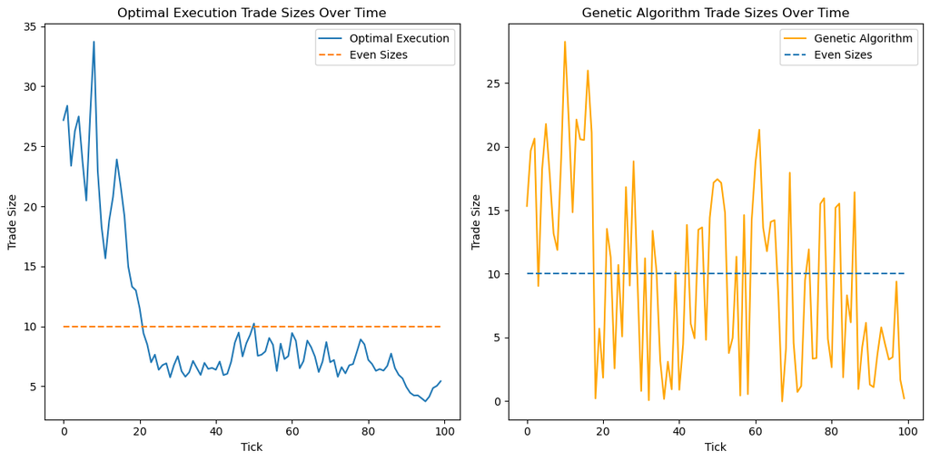

```python
# Calculate the even trade sizes
n = len(simulator.order_book_history)
even_trade_sizes = [1000 / n] * n

# Plot the trade sizes over time for both strategies
fig, axs = plt.subplots(1, 2, figsize=(12, 6))

# Plot the trade sizes over time for the OptimalExecution strategy
axs[0].plot(trade_sizes_optimal, label="Optimal Execution")
axs[0].plot(even_trade_sizes, label="Even Sizes", linestyle="--")
axs[0].set_title("Optimal Execution Trade Sizes Over Time")
axs[0].set_xlabel("Tick")
axs[0].set_ylabel("Trade Size")
axs[0].legend()

# Plot the trade sizes over time for the OptimalExecutionGA strategy
axs[1].plot(trade_sizes_ga, label="Genetic Algorithm", color="orange")
axs[1].plot(even_trade_sizes, label="Even Sizes", linestyle="--")
axs[1].set_title("Genetic Algorithm Trade Sizes Over Time")
axs[1].set_xlabel("Tick")
axs[1].set_ylabel("Trade Size")
axs[1].legend()

plt.tight_layout()
plt.show()
```

When comparing the Trade Sizes over time, we evidently see larger tradesizes where the spread is smaller and vice versa. Indicating that our model performs as expected. In this notebook, the spread between the VWAP's act as a proxy for the depth of the orderbook and the potential price impact. Based on both the total cost and the plots, we observe that the Genetic Algorithm underperforms and CVXPY shows the best results.

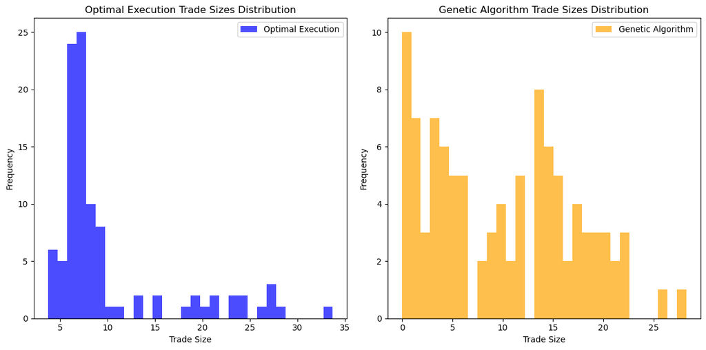

```python
# Plot the histograms of the trade sizes for both strategies
fig, axs = plt.subplots(1, 2, figsize=(12, 6))

# Plot the histogram of the trade sizes for the OptimalExecution strategy
axs[0].hist(
    trade_sizes_optimal, bins=30, label="Optimal Execution", color="blue", alpha=0.7
)
axs[0].set_title("Optimal Execution Trade Sizes Distribution")
axs[0].set_xlabel("Trade Size")
axs[0].set_ylabel("Frequency")
axs[0].legend()

# Plot the histogram of the trade sizes for the OptimalExecutionGA strategy
axs[1].hist(
    trade_sizes_ga, bins=30, label="Genetic Algorithm", color="orange", alpha=0.7
)
axs[1].set_title("Genetic Algorithm Trade Sizes Distribution")
axs[1].set_xlabel("Trade Size")
axs[1].set_ylabel("Frequency")
axs[1].legend()

plt.tight_layout()
plt.show()
```

In the trade size histograms we can once again notice how the first method takes advantage of the lower spread in a more aggressive manner than the GA method, granting a superior result.

# Part 3: Option pricing

Options are a type of financial derivative that give the holder the right, but not the obligation, to buy or sell an underlying asset at a specified price, known as the strike price, before or on a specified date, known as the expiration date. There are two main types of options: call options, which give the holder the right to buy the underlying asset, and put options, which give the holder the right to sell the underlying asset.

[figure not shown]

Options explained

Option pricing is the process of determining the fair price of an option. This is a complex task because the price of an option depends on various factors, including the price of the underlying asset, the strike price, the time to expiration, the risk-free interest rate, and the volatility of the underlying asset's returns [5].

The Black-Scholes model is one of the most well-known models for option pricing. It was developed by economists Fischer Black and Myron Scholes, with contributions from Robert Merton. The Black-Scholes model assumes that financial markets are efficient and that the returns of the underlying asset follow a geometric Brownian motion with constant volatility [6].

[figure not shown]

Fischer Black and Myron Scholes

The Black-Scholes formula for the price of a European call option is:

$$C = S_0 N(d_1) - X e^{-rt} N(d_2)$$

and for a European put option is:

$$P = X e^{-rt} N(-d_2) - S_0 N(-d_1)$$

Where:

$$d_1 = \frac{ln(\frac{S_0}{X}) + (r + \frac{\sigma^2}{2})t}{\sigma \sqrt{t}}$$

$$d_2 = d_1 - \sigma \sqrt{t}$$

- C is the price of the call option
- P is the price of the put option
- $S_0$ is the price of the underlying asset
- X is the strike price
- r is the risk-free interest rate
- t is the time to expiration
- N is the cumulative distribution function of the standard normal distribution
- $σ$ is the volatility of the underlying asset's returns
- $d1$ and $d2$ are intermediate variables used in the formulas

The optimization process in this code is aiming to calibrate the Black-Scholes model by finding the optimal volatility parameter (sigma) that minimizes the discrepancy between the model's predicted option prices and the actual market prices.

Mathematically, this is achieved by solving the following optimization problem:

minimize: $Σ$ (P_model(i, sigma) - P_market(i))$^2$

where:

- P_model(i, sigma) is the price of the i-th option as predicted by the Black-Scholes model with volatility $sigma$
- P_market(i) is the actual market price of the i-th option,
- The sum is over all options available for the given stock.

The scipy.optimize.minimize function is used to perform this optimization. It iteratively adjusts the sigma value to find the minimum of the objective function. The used methods of optimization are 'Nelder-Mead', 'CG', 'BFGS', 'SLSQP' and it starts with an initial guess for sigma of 0.5.

The result of the optimization is the sigma value that best aligns the Black-Scholes model prices with the observed market prices, under the assumption of constant volatility. This calibrated model can then be used for more accurate option pricing and strategy development.

The 4 companies that will be used for this are 2 American prides Tesla and Apple, and 2 Belgian prides Argenx and Euronav.

```python
# List of ticker symbols
ticker_symbols = ["TSLA", "AAPL", "ARGX", "EURN"]

methods = ["Nelder-Mead", "CG", "BFGS", "SLSQP"]


class OptionPricingModel:
    def __init__(self, ticker_symbol, risk_free_rate=0.01):
        self.ticker = yf.Ticker(ticker_symbol)
        self.risk_free_rate = risk_free_rate

    def fetch_option_data(self):
        expiration_date = self.ticker.options[
            0
        ]  # Use the first available expiration date
        options = self.ticker.option_chain(expiration_date)
        self.calls = options.calls

    def calculate_time_to_maturity(self):
        expiration_date = self.ticker.options[0]
        self.T = (pd.to_datetime(expiration_date) - pd.Timestamp.today()).days / 365.0

    def calculate_spot_price(self):
        self.S = self.ticker.info["regularMarketPreviousClose"]

    def black_scholes(self, sigma):
        d1 = (
            np.log(self.S / self.calls["strike"])
            + (self.risk_free_rate + 0.5 * sigma**2) * self.T
        ) / (sigma * np.sqrt(self.T))
        d2 = d1 - sigma * np.sqrt(self.T)
        call_prices = self.S * si.norm.cdf(d1, 0.0, 1.0) - self.calls[
            "strike"
        ] * np.exp(-self.risk_free_rate * self.T) * si.norm.cdf(d2, 0.0, 1.0)
        call_prices[np.isnan(call_prices)] = -np.inf
        return call_prices

    def optimize_volatility(self, method="Nelder-Mead", sigma_initial=0.5):
        result = minimize(self.objective_function, sigma_initial, method=method)
        self.optimal_sigma = result.x[0]
        print(
            f"Optimization method: {method}, Optimal sigma: {self.optimal_sigma}, Objective function value: {result.fun}"
        )

    def objective_function(self, sigma):
        model_prices = self.black_scholes(sigma)
        market_prices = self.calls["lastPrice"].values
        return np.sum((model_prices - market_prices) ** 2)

    def compare_prices(self):
        model_prices = self.black_scholes(self.optimal_sigma)
        comparison = pd.DataFrame(
            {
                "Strike Price": self.calls["strike"],
                "Market Price": self.calls["lastPrice"],
                "Model Price": model_prices,
            }
        )
        return comparison


def plot_comparisons(comparison_results, models, methods):
    fig, axs = plt.subplots(2, 2, figsize=(12, 8))
    axs = axs.flatten()

    for i, (comparison_result, model, method) in enumerate(
        zip(comparison_results, models, methods)
    ):
        axs[i].scatter(
            comparison_result["Strike Price"],
            comparison_result["Market Price"],
            label="Market Price",
            color="blue",
        )
        axs[i].scatter(
            comparison_result["Strike Price"],
            comparison_result["Model Price"],
            label="Model Price",
            color="red",
            marker="x",
        )
        axs[i].set_xlabel("Strike Price")
        axs[i].set_ylabel("Option Price")
        axs[i].set_title(f"{method} for {model.ticker.ticker}")
        axs[i].legend()
        axs[i].grid(True)

        mae = mean_absolute_error(
            comparison_result["Market Price"], comparison_result["Model Price"]
        )
        rmse = np.sqrt(
            mean_squared_error(
                comparison_result["Market Price"], comparison_result["Model Price"]
            )
        )
        r_squared = r2_score(
            comparison_result["Market Price"], comparison_result["Model Price"]
        )

        axs[i].annotate(
            f"MAE: {mae:.4f}",
            xy=(0.45, 0.85),
            xycoords="axes fraction",
            fontsize=10,
            color="blue",
        )
        axs[i].annotate(
            f"RMSE: {rmse:.4f}",
            xy=(0.45, 0.80),
            xycoords="axes fraction",
            fontsize=10,
            color="red",
        )
        axs[i].annotate(
            f"R-squared: {r_squared:.4f}",
            xy=(0.45, 0.75),
            xycoords="axes fraction",
            fontsize=10,
            color="green",
        )

    plt.tight_layout()
    plt.show()
```

## A. BFGS

```python
# Create empty lists to store comparison results and models
comparison_results = []
models = []
method = "BFGS"

# Loop over ticker symbols
for ticker_symbol in ticker_symbols:
    # Create an OptionPricingModel instance for the current ticker
    model = OptionPricingModel(ticker_symbol)
    model.fetch_option_data()
    model.calculate_time_to_maturity()
    model.calculate_spot_price()
    model.optimize_volatility(method=method)
    models.append(model)
    comparison_result = model.compare_prices()
    comparison_results.append(comparison_result)
```

```
Optimization method: BFGS, Optimal sigma: 0.6026927324274821, Objective function value: 84.3682064127492
Optimization method: BFGS, Optimal sigma: 0.5776877394386964, Objective function value: 60.1230618288063
Optimization method: BFGS, Optimal sigma: 0.49113641212669534, Objective function value: 16355.980154102333
Optimization method: BFGS, Optimal sigma: 2.1148482385230087, Objective function value: 43.188690537168405
```

## B. Nelder-Mead

```python
# Create empty lists to store comparison results and models
comparison_results = []
models = []
method = "Nelder-Mead"
# Loop over ticker symbols
for ticker_symbol in ticker_symbols:
    # Create an OptionPricingModel instance for the current ticker
    model = OptionPricingModel(ticker_symbol)
    model.fetch_option_data()
    model.calculate_time_to_maturity()
    model.calculate_spot_price()
    model.optimize_volatility(method=method)
    models.append(model)
    comparison_result = model.compare_prices()
    comparison_results.append(comparison_result)
```

```
Optimization method: Nelder-Mead, Optimal sigma: 0.6027343750000004, Objective function value: 84.36820749259412
Optimization method: Nelder-Mead, Optimal sigma: 0.5777343750000002, Objective function value: 60.12306328630681
Optimization method: Nelder-Mead, Optimal sigma: 0.49111328125, Objective function value: 16355.98015632016
Optimization method: Nelder-Mead, Optimal sigma: 2.114843750000003, Objective function value: 43.18869053723402
```

## C. Conjugate Gradient

```python
# Create empty lists to store comparison results and models
comparison_results = []
models = []
method = "CG"
# Loop over ticker symbols
for ticker_symbol in ticker_symbols:
    # Create an OptionPricingModel instance for the current ticker
    model = OptionPricingModel(ticker_symbol)
    model.fetch_option_data()
    model.calculate_time_to_maturity()
    model.calculate_spot_price()
    model.optimize_volatility(method=method)
    models.append(model)
    comparison_result = model.compare_prices()
    comparison_results.append(comparison_result)
```

```
Optimization method: CG, Optimal sigma: 0.6026927161618376, Objective function value: 84.36820641274858
Optimization method: CG, Optimal sigma: 0.5776877335018821, Objective function value: 60.12306182880649
Optimization method: CG, Optimal sigma: 0.4911364072277713, Objective function value: 16355.980154102337
Optimization method: CG, Optimal sigma: 2.1148479216372835, Objective function value: 43.188690537168
```

## D. SLSQP

```python
# Create empty lists to store comparison results and models
comparison_results = []
models = []
method = "SLSQP"
# Loop over ticker symbols
for ticker_symbol in ticker_symbols:
    # Create an OptionPricingModel instance for the current ticker
    model = OptionPricingModel(ticker_symbol)
    model.fetch_option_data()
    model.calculate_time_to_maturity()
    model.calculate_spot_price()
    model.optimize_volatility(method=method)
    models.append(model)
    comparison_result = model.compare_prices()
    comparison_results.append(comparison_result)
```

```
Optimization method: SLSQP, Optimal sigma: 0.6026819942522817, Objective function value: 84.36820648429064
Optimization method: SLSQP, Optimal sigma: 0.5776878029129875, Objective function value: 60.123061828808424
Optimization method: SLSQP, Optimal sigma: 0.49113461591726587, Objective function value: 16355.980154115688
Optimization method: SLSQP, Optimal sigma: 2.1146664449431913, Objective function value: 43.18869066334123
```

## E. Visualizations

All methods perform nearly identical, showing no obvious winner, here we visualize them.

```
Optimization method: Nelder-Mead, Optimal sigma: 0.5095703125, Objective function value: 180.8829929931181
Optimization method: CG, Optimal sigma: 0.3490351336217695, Objective function value: 115.34744930848335
Optimization method: BFGS, Optimal sigma: 0.9921253089993534, Objective function value: 22807.73434807648
Optimization method: SLSQP, Optimal sigma: 1.5804885993349973, Objective function value: 40.78896806242823
```

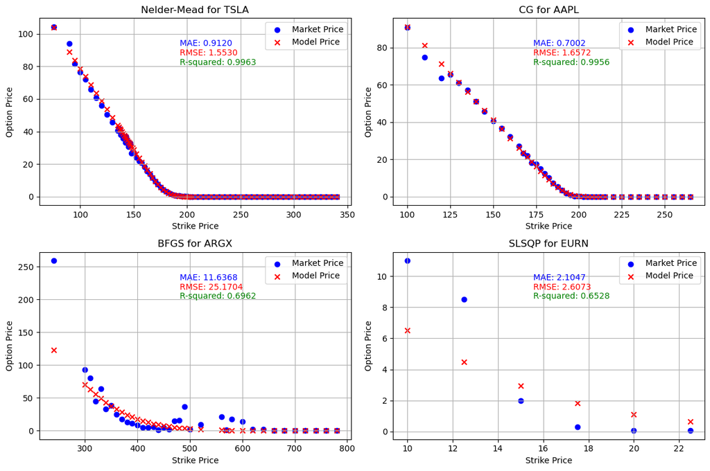

```python
for ticker_symbol, method in zip(ticker_symbols, methods):
    model = OptionPricingModel(ticker_symbol)
    model.fetch_option_data()
    model.calculate_time_to_maturity()
    model.calculate_spot_price()
    model.optimize_volatility(method=method)
    models.append(model)
    comparison_result = model.compare_prices()
    comparison_results.append(comparison_result)

plot_comparisons(comparison_results, models, methods)
```

Ideally, we want to see the red crosses (model prices) closely align with the blue dots (market prices). This would indicate that the Black-Scholes model, with the optimized volatility parameter, is accurately predicting the market prices of the options.

Overall we see great result with large R-squared values for larger companies such as Apple and Tesla, but worse predictions for smaller companies such as Argenx and Euronav.

For larger companies like Tesla and Apple, the options markets are typically more liquid and efficient. This means there are more market participants and more transactions, leading to more accurate market prices. These conditions are well-suited for the Black-Scholes model, which assumes an efficient market, leading to a better fit (higher R-squared value).

On the other hand, for smaller companies, the options markets may be less liquid and less efficient. There may be fewer market participants and transactions, leading to less accurate market prices. These conditions are less suitable for the Black-Scholes model, leading to a worse fit (lower R-squared value).

It's also worth noting that the Black-Scholes model assumes constant volatility, which may not be a valid assumption for smaller companies with less stable stock prices. This could also contribute to the worse fit for these companies.

# Part 4: Hedging by Simulated Annealing

Hedging is a risk management strategy used in finance to protect an investment portfolio against adverse price movements. It involves the use of financial instruments, such as options, to offset potential losses in the underlying assets [7]. In the context of a stock portfolio, hedging can be achieved by purchasing options contracts. These can be used in several ways:

1. Protective Puts: Buying put options on stocks you own can protect against a decline in the stock price. If the stock price falls, the increase in the put option's value can offset the loss on the stock.
2. Covered Calls: If you own a stock and sell a call option on it (a "covered call"), you can generate income from the option premium. This can offset potential losses if the stock price falls. However, if the stock price rises above the strike price, you may have to sell the stock at a lower price.
3. Index Options: If you have a diversified portfolio, you can hedge against market risk by buying put options on a stock index. If the market falls, the increase in the value of the put option can offset the loss on the portfolio.

For instance, a protective put acts as an insurance policy, where the put option will increase in value if the stock price falls, offsetting the loss in the stock's value. The goal of hedging is not necessarily to make profits but to reduce the potential for loss. The cost of this protection is the premium paid for the options contracts, which can be considered as the cost of insurance.

In this part of the notebook, we are using a simulated annealing algorithm to find the optimal weights of stocks in your portfolio **to minimize the hedging cost**. This is a sophisticated approach to hedging, which seeks to find the most cost-effective way to protect the portfolio against price volatility.

[figure not shown]

**Simulated Annealing** is a probabilistic optimization algorithm inspired by the annealing process in metallurgy. It's used to find the global minimum of a function that may have multiple local minima.

The algorithm starts with a random solution and explores the solution space by generating neighboring solutions. If a neighboring solution provides a better outcome, it's accepted. If it's worse, it may still be accepted with a certain probability, which decreases over time according to a cooling schedule. This probabilistic acceptance helps the algorithm avoid getting trapped in local minima.

Over time, as the "temperature" decreases, the algorithm reduces the probability of accepting worse solutions, gradually focusing on exploring around the current best solution. This allows the algorithm to balance exploration (searching the entire solution space) and exploitation (refining the current best solution), ultimately converging to a global minimum.

[figure not shown]

The Simulated Annealing algorithm is used to solve the constrained optimization problem in this code.

The objective function is the normalized hedging cost: $H(w) = \frac{\sum_{i=1}^{n} |w_i| \cdot o_{i,1} \cdot o_{i,2}}{\bar{P}}$

Subject to constraints:

$∑w_i = 1$, for all i in {1, 2, ..., n}

$0 ≤ w_i ≤ 1$, for all i in {1, 2, ..., n}

Where:

- $H(w)$ is the normalized hedging cost
- $w_i$ is the weight of the i-th stock in the portfolio
- $o_{i,1}$ and $o_{i,2}$ are the last price and strike price of the option for the i-th stock, respectively
- $\bar{P}$ is the mean portfolio value
- n is the number of stocks in the portfolio

```python
def fetch_stock_data(tickers, start_date, end_date):
    stock_data = yf.download(tickers, start=start_date, end=end_date)["Adj Close"]
    return stock_data


def fetch_option_data(tickers):
    option_data = []
    successful_tickers = []
    for ticker in tickers:
        try:
            ticker_obj = yf.Ticker(ticker)
            options = ticker_obj.options
            if options:
                data = ticker_obj.option_chain(options[0])
                option_data.append(
                    [data.calls["lastPrice"][0], data.calls["strike"][0]]
                )
                successful_tickers.append(ticker)
        except Exception as e:
            print(f"Error fetching data for {ticker}: {e}")
    return np.array(option_data), successful_tickers


def calculate_hedging_cost(weights, stock_data, option_data):
    portfolio_value = np.sum(stock_data * weights, axis=1)
    hedging_cost = np.sum(np.abs(weights) * option_data[:, 0] * option_data[:, 1])
    return hedging_cost / np.mean(portfolio_value)


def simulated_annealing(
    objective_function,
    num_dimensions,
    lb,
    ub,
    max_iter=1000,
    initial_temperature=100,
    final_temperature=0.1,
    cooling_rate=0.85,
    sigma=2,
    NT=5,
):
    current_solution = np.random.uniform(lb, ub, num_dimensions)
    current_solution /= np.sum(current_solution)  # Normalize the weights
    current_value = objective_function(current_solution, stock_data, option_data)

    best_solution = np.copy(current_solution)
    best_value = current_value

    temperature = initial_temperature

    # Initialize lists to store the best values and temperatures at each iteration
    best_values = []
    temperatures = []

    for _ in range(max_iter):
        for _ in range(NT):  # Repeat NT times at each temperature
            new_solution = current_solution + np.random.normal(
                0, sigma, num_dimensions
            )  # Generate new solution using a Gaussian distribution
            new_solution = np.clip(new_solution, lb, ub)
            new_solution /= np.sum(new_solution)  # Normalize the weights

            new_value = objective_function(new_solution, stock_data, option_data)

            if new_value < current_value or random.random() < math.exp(
                -(new_value - current_value) / temperature
            ):
                current_solution = np.copy(new_solution)
                current_value = new_value

                if new_value < best_value:
                    best_solution = np.copy(new_solution)
                    best_value = current_value

        temperature *= cooling_rate

        # Append the best value and temperature to the lists
        best_values.append(best_value)
        temperatures.append(temperature)

    return best_solution, best_value, best_values, temperatures
```

```python
# List of S&P 500 tickers
stock_tickers = sp500_tickers

start_date = "2022-01-01"
end_date = "2022-12-31"
stock_data = fetch_stock_data(stock_tickers, start_date, end_date)
option_data, successful_tickers = fetch_option_data(stock_tickers)

# Filter stock_data to only include successful tickers
stock_data = stock_data[successful_tickers]
```

```python
num_dimensions = len(successful_tickers)
lb = np.zeros(num_dimensions)
ub = np.ones(num_dimensions)

optimal_solution, optimal_value, best_values, temperatures = simulated_annealing(
    calculate_hedging_cost, num_dimensions, lb, ub, cooling_rate=0.95, max_iter=1000
)
```

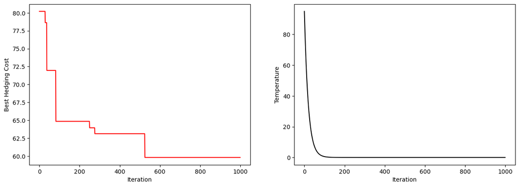

```python
# Plot the best function value at each iteration
plt.figure(figsize=(15, 5))
plt.subplot(1, 2, 1)
plt.plot(best_values, color="red")
plt.xlabel("Iteration")
plt.ylabel("Best Hedging Cost")

# Plot the temperature at each iteration
plt.subplot(1, 2, 2)
plt.plot(temperatures, color="black")
plt.xlabel("Iteration")
plt.ylabel("Temperature")

plt.show()
```

```python
print("Optimal value (hedging cost):", optimal_value)
```

```
Optimal value (hedging cost): 59.807505664855384
```

After tuning the hyperparameters to allow for more extensive search of the solution space, the algorithm converged to an optimal hedging cost of approximately 59.81. This result indicates that the optimal portfolio configuration found by the algorithm minimizes the cost of hedging against potential losses.

**FINANCIAL DISCLAIMER: The content of this project is for informational purposes only, not financial advice.**

## References

1. Markowitz, H. (1952). Portfolio Selection. The Journal of Finance, 7(1), 77–91. DOI: 10.2307/2975974
2. Markowitz, H. (1959). Portfolio Selection: Efficient Diversification of Investments. Yale University Press.
3. Sharpe, W. F. (1966). Mutual Fund Performance. Journal of Business, 39(1), 119–138. DOI: 10.1086/294846
4. Almgren, R., & Chriss, N. (2000). Optimal execution of portfolio transactions. Journal of Risk, 3, 5-39.
5. Merton, R. C. (1973). Theory of Rational Option Pricing. The Bell Journal of Economics and Management Science, 4(1), 141-183. DOI: 10.2307/3003143
6. Black, F., & Scholes, M. (1973). The Pricing of Options and Corporate Liabilities. Journal of Political Economy, 81(3), 637-654. DOI: 10.1086/260062
7. Hull, J., & White, A. (1987). The Pricing of Options on Assets with Stochastic Volatilities. The Journal of Finance, 42(2), 281-300. DOI: 10.1111/j.1540-6261.1987.tb02568.x